# WNBA 2025 Game Attendance: Inaugural Teams vs. the WNBA’s Newest Teams

Political Science 270 Final Project

Betty Fox

## Data Set

```r
all_game_attendance <- read_csv("Data/All Game Attendance.csv")
  all_game_attendance
```

```
# A tibble: 6,525 × 13
    ...1  Year `Day of Week` Month   Day `Time (ET)` `Game Type`
   <dbl> <dbl> <chr>         <chr> <dbl> <time>      <chr>
 1     1  1997 Saturday      June     21 16:00       Regular season
 2     2  1997 Saturday      June     21 19:00       Regular season
 3     3  1997 Saturday      June     21 05:00       Regular season
 4     4  1997 Sunday        June     22 16:00       Regular season
 5     5  1997 Monday        June     23 03:00       Regular season
 6     6  1997 Monday        June     23 22:00       Regular season
 7     7  1997 Tuesday       June     24 04:00       Regular season
 8     8  1997 Wednesday     June     25 06:00       Regular season
 9     9  1997 Thursday      June     26 19:00       Regular season
10    10  1997 Thursday      June     26 22:00       Regular season
# ℹ 6,515 more rows
# ℹ 6 more variables: `Home Team` <chr>, `Away Team` <chr>,
#   Arena <chr>, City <chr>, State <chr>, Attendance <dbl>
```

## Introduction

The Woman’s National Basketball Association (WNBA) was founded in 1997 and originally comprised eight teams. In 2025 four teams of the original eight were still in the league. In 2025 the WNBA included 13 teams in the league. More support and spotlight has been on individual players and the league as a whole. It is important to note that in the data set the Utah Starzz are deemed an original team that are still in the league although they disbanded in 2002. This is because the Utah Starzz became the San Antonio Stars with the same players in 2003. The San Antonio Stars then became the Las Vegas Aces in 2018 with the same players from the San Antonio Stars 2017 season.

Does a team being a member of the WNBA since its founding increase away game attendance? Or do the newest four WNBA teams in 2025 get higher attendance at away games? I hypothesize that the inaugural teams` away game attendance have loyal fans but not as many compared to newer teams. This is because newer teams gain traction because of their players’ skills. While inaugural teams fans are loyal and likely have supported the team since the beginning. Therefore, the amount of support is less likely to increase without the excitement of a new team or a new player. This question is important because the WNBA is under research. Since it is a relatively new league there are few data sets and historical information available about the league. Unlike the NBA which has been around for 77 years and is well known by the general public. Given that this research question is focused on an all women league, sexism plays a role. This fact makes this research question more interesting and important to analyze.

## Data

| avg_attendance |
| --- |
| 8217.57 |

On average 8,218 people attend a WNBA game.

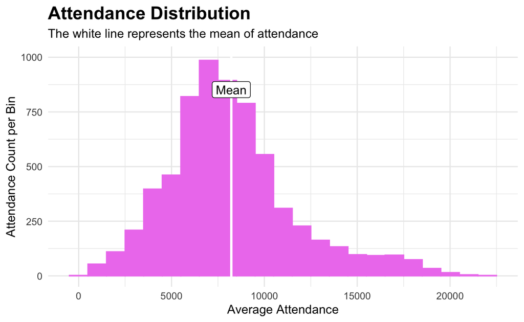

The data source is called “All Game Attendance” and it measures the date of WNBA games, the home and away teams playing, attendance, game type, arena, and game location. The dependent variable of my analysis is attendance and my independent variable is the type of Away Team. The four inaugural teams that are still in the WNBA in 2025 and the four newest WNBA teams in 2025. The dependent variable, attendance, is measured quantitatively. This is because the researcher was able to find the number of fan attendance and it allows you to compute the mean and standard deviation of the variable. The Away team is measured by observation. In the data set the researcher only states which team is playing as the “Home Team” or the “Away Team.” The knowledge about which teams joined the league more recently or in 1997 comes from outside knowledge.

To support my hypothesis the newer WNBA teams would have to have a higher average away game attendance than newer WNBA teams. I would also have to see that my regression showed a positive and statistically significant number for the independent variable. This would represent that newer teams have a higher and different away game attendance than inaugural WNBA teams. To reject my hypothesis the inaugural WNBA teams would have to have an average attendance at away games that is equal or higher than the newest WNBA teams in 2025. The regression for the independent variables would also have to be a negative number or not statistically significant. This would show me that there was no relationship between attendance and year of joining the league.

## Results

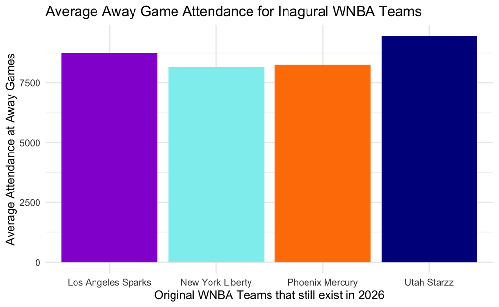

```
# A tibble: 1,666 × 2
# Groups:   Away Team [4]
   `Away Team`        Attendance
   <chr>                   <dbl>
 1 New York Liberty        14284
 2 Los Angeles Sparks       8036
 3 New York Liberty        15259
 4 Phoenix Mercury         16285
 5 Utah Starzz              8845
 6 New York Liberty         8931
 7 Phoenix Mercury          5930
 8 Phoenix Mercury         17780
 9 Los Angeles Sparks       8301
10 Utah Starzz              6156
# ℹ 1,656 more rows
```

```
# A tibble: 4 × 5
  term                        estimate std.error statistic p.value
  <chr>                          <dbl>     <dbl>     <dbl>   <dbl>
1 (Intercept)                    8763.      150.     58.2  0
2 `Away Team`New York Liberty    -604.      213.     -2.83 0.00465
3 `Away Team`Phoenix Mercury     -506.      212.     -2.39 0.0171
4 `Away Team`Utah Starzz          694.      380.      1.83 0.0679
```

Intercept (Los Angeles Sparks): According to the regression at Los Angeles Sparks, away games attendance on average is about 8763 people.

New York Liberty: The New York Liberty away game attendance has about 604 spectators less than the Los Angeles Sparks away games.

Phoenix Mercury: The Phoenix Mercury away game attendance has about 506 spectators less than the Los Angeles Sparks away games.

Utah Starzz: The Utah Starzz away game attendance has about 694 spectators more than the Los Angeles Sparks away games.

Given that the average attendance at WNBA games is approximately 8,218 spectators, a decrease of about 500 to 600 attendees represents a noticeable but moderate reduction in crowd size. This difference in attendance demonstrates that the team itself does not play as large of a role in fan attendance at away games for inaugural teams in the WNBA. Across these four teams, the differences across game attendance mostly stayed the same, besides for the Utah Starzz who increased their game attendance. The only team in this regression model to do so.

We should not interpret the coefficient causally because there are confounding variables. Meaning other elements that impact the treatment and the outcome variables. The confounding variable in this regression model is player popularity. In recent years there has been a lot of press about great players like Caityln Clark, for example, on Indiana Fever. If the opponent of these inaugural teams are the Indiana Fever, or other teams with well known players there might be increased attendance. The data set does not disclose which team the fans were rooting for at the games. Therefore, it is likely that although some teams have higher away game attendance that higher number does not only come from the inaugural team playing in another arena.

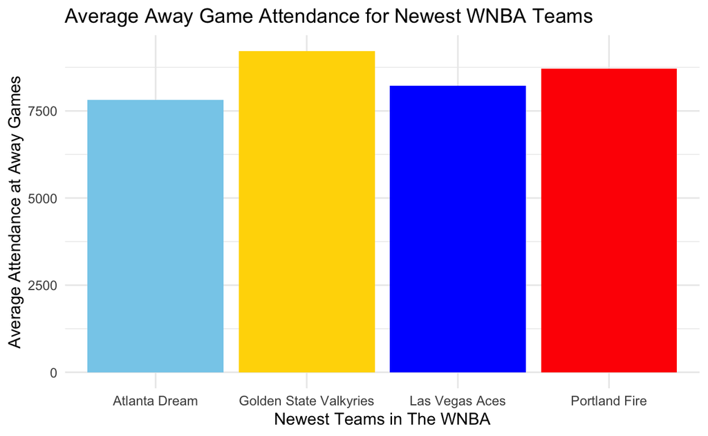

```
# A tibble: 541 × 2
# Groups:   Away Team [4]
   `Away Team`   Attendance
   <chr>              <dbl>
 1 Portland Fire      10182
 2 Portland Fire       4639
 3 Portland Fire       9919
 4 Portland Fire       7127
 5 Portland Fire      11543
 6 Portland Fire       6661
 7 Portland Fire      12060
 8 Portland Fire      12693
 9 Portland Fire       4416
10 Portland Fire       6131
# ℹ 531 more rows
```

```
# A tibble: 4 × 5
  term                          estimate std.error statistic   p.value
  <chr>                            <dbl>     <dbl>     <dbl>     <dbl>
1 (Intercept)                      7820.      208.     37.6  1.33e-152
2 `Away Team`Golden State Valk…    1394.      808.      1.73 8.49e-  2
3 `Away Team`Las Vegas Aces         403.      373.      1.08 2.80e-  1
4 `Away Team`Portland Fire          892.      579.      1.54 1.24e-  1
```

Intercept (Atlanta Dream): According to the regression the Atlanta Dream away game attendance on average has about 7820 people.

Golden State Valkyries: Golden State Valkyries away games have about 1394 spectators more than Atlanta Dream away games.

Las Vegas Aces: Las Vegas Aces away games have about 403 more spectators than Atlanta Dream away games.

Portland Fire: Portland Fire away games have about 892 more spectators than Atlanta Dream away games.

## Possible Confounder Analysis

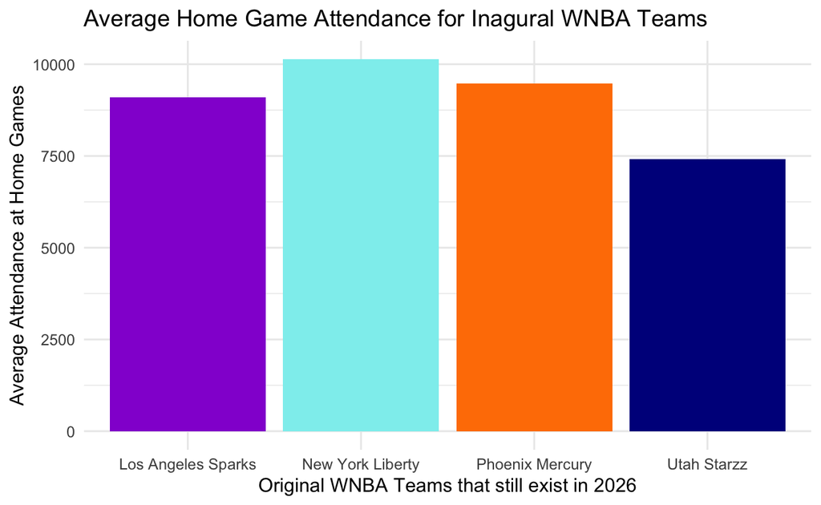

```
# A tibble: 1,666 × 2
# Groups:   Home Team [4]
   `Home Team`        Attendance
   <chr>                   <dbl>
 1 Los Angeles Sparks      14284
 2 Utah Starzz              8915
 3 Phoenix Mercury         16102
 4 Utah Starzz              8036
 5 Los Angeles Sparks       6397
 6 Los Angeles Sparks       6670
 7 Utah Starzz              6529
 8 New York Liberty        17780
 9 New York Liberty         8792
10 Utah Starzz              6718
# ℹ 1,656 more rows
```

```
# A tibble: 4 × 5
  term                        estimate std.error statistic     p.value
  <chr>                          <dbl>     <dbl>     <dbl>       <dbl>
1 (Intercept)                    9093.      149.     61.1  0
2 `Home Team`New York Liberty    1043.      210.      4.96 0.000000769
3 `Home Team`Phoenix Mercury      387.      210.      1.84 0.0662
4 `Home Team`Utah Starzz        -1682.      378.     -4.46 0.00000893
```

Intercept (Los Angeles Sparks): According to the regression at Los Angeles Sparks, home games attendance on average is about 9,092 people.

New York Liberty: The New York Liberty home game attendance has about 1,042 more spectators than the Los Angeles Sparks home games.

Phoenix Mercury: The Phoenix Mercury home game attendance has about 387 more spectators than the Los Angeles Sparks home games.

Utah Starzz: The Utah Starzz away game attendance has about 1,682 less spectators than the Los Angeles Sparks home games.

Home game attendance for the inaugural teams in the WNBA that were still in the league in 2025’s attendance differs. s not the same across the board. Attendance at these four teams’ home games are based on the individual team. For example , the New York Liberty have a higher average home game attendance than the Los Angeles Sparks by about 1,000 people more. You can not interpret this causally because of the accessibility fans have to their home team arenas. In New York City the Barclay Center, where the New York Liberty plays, is very accessible. You can attend via subway which is only three dollars per ride. While in many other cities such as Phoenix, Arizona and Salt Lake City, Utah there is limited public transportation to the arenas. The only way people attend these games is by using cars but not everyone has access to a car or owns one. Therefore there is an automatic disadvantage: less wealthy people have to even attend the games in person. Even if the games are being played in their home town or city.

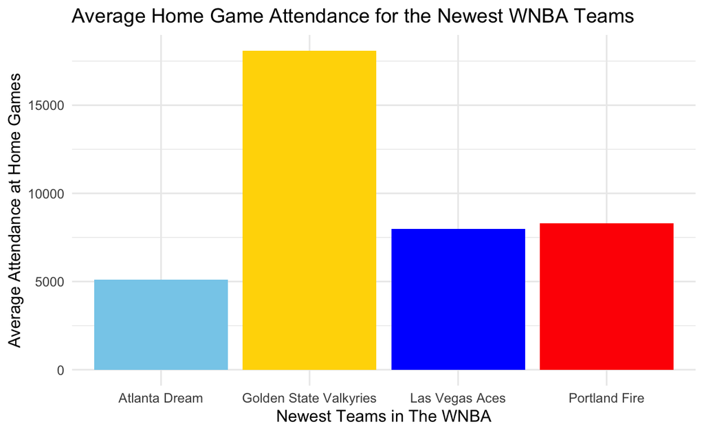

```
# A tibble: 550 × 2
# Groups:   Home Team [4]
   `Home Team`   Attendance
   <chr>              <dbl>
 1 Portland Fire      10277
 2 Portland Fire       8194
 3 Portland Fire       7738
 4 Portland Fire       8703
 5 Portland Fire       6569
 6 Portland Fire       9390
 7 Portland Fire       7014
 8 Portland Fire       7703
 9 Portland Fire       8613
10 Portland Fire       8155
# ℹ 540 more rows
```

```
# A tibble: 4 × 5
  term                          estimate std.error statistic   p.value
  <chr>                            <dbl>     <dbl>     <dbl>     <dbl>
1 (Intercept)                      5114.      154.     33.2  2.90e-133
2 `Home Team`Golden State Valk…   12970.      594.     21.8  2.13e- 76
3 `Home Team`Las Vegas Aces        2860.      267.     10.7  2.02e- 24
4 `Home Team`Portland Fire         3205.      426.      7.52 2.24e- 13
```

Intercept (Atlanta Dream): According to the regression the Atlanta Dream home game attendance on average has about 5, 114 people.

Golden State Valkyries: Golden State Valkyries home games have about 12,970 spectators more than Atlanta Dream home games.

Las Vegas Aces: Las Vegas Aces home games have about 2,860 more spectators than Atlanta Dream home games.

Portland Fire: Portland Fire home games have about 3,204 more spectators than Atlanta Dream home games.

We should not interpret the coefficient causally, meaning that the treatment home game attendance is the sole cause for driving home game attendance up or down. The year that the newest WNBA teams were added to the league as of 2025 is a confounding variable. Year impacts the independent variable, the team, being created and the dependent variable, attendance. Over time there has been more support and overall interest in the WNBA and other woman’s sports. The Golden State Valkyries were founded in February of 2025 while the Atlanta Dream, the intercept, was founded in 2007. The excitement and willingness for the general public to engage with WNBA teams increases attendance. It makes Golden State Valkyries home games to have higher attendance because people are excited about the team, interested in the WNBA. Therefore, attendance is much higher for the Golden State Valkyries than other newest WNBA teams as of 2025.

## Conclusion

Despite these patterns, the findings cannot be interpreted causally due to several limitations and confounding variables. Some confounding variables that influence attendance, include player popularity, social media attention, arena accessibility, and broader growth in interest in women’s basketball. For example, increased visibility of star players and social media coverage in recent years may increase attendance for newer teams compared to older ones. Additionally, the data set does not distinguish between fans supporting home versus away teams, which limits the ability to isolate true fan base effects.

If I had more time and money, I would improve this analysis by adding a variable that looked at how individual players on rosters increase or decrease game attendance. Unlike the NBA the WNBA has a culture of loyalty for individual players in addition to support for a team. This is because there is an all star game where most valued players from different teams play against each other. This can affect game attendance because it is more likely that a fan would watch a great player compared to a mediocre one.

```r
library(ggplot2)
library(dplyr)
library(tidyverse)
library(infer)
all_game_attendance <- read_csv("Data/All Game Attendance.csv")
  all_game_attendance

avg_attendance <- all_game_attendance |>
  summarize(avg_attendance = mean(Attendance, na.rm = TRUE))
knitr::kable(avg_attendance, digit = 2)
avg_attendance_hist <- all_game_attendance |>
  ggplot(mapping = aes(x = Attendance)) +
  geom_histogram(binwidth = 1000, fill = "violet", color = "violet") +
  geom_vline(xintercept = avg_attendance$avg_attendance, color = "white", linewidth = 1) +
  annotate(
  "label",
  x = avg_attendance$avg_attendance,
  y = 1000,
  label = "Mean",
  angle = 360,
  vjust = 2.5
) +
  labs(x = "Average Attendance",
       y = "Attendance Count per Bin",
       title = "Attendance Distribution",
       subtitle = "The white line represents the mean of attendance") +
  theme_minimal() +
  theme(
    plot.title = element_text(size = 16, face = "bold"))
    panel.grid.minor = element_blank()
avg_attendance_hist
inaguralWNBA_awaybar <- all_game_attendance |>
   select(-Year,
         -`Day of Week`,
         -Month, -Day,
         -`Time (ET)`,
         -`Home Team`,
         -Arena,
         -City,
         -State,
         -`Game Type`,
         -1) |>
   filter(`Away Team` %in% c("Los Angeles Sparks",
                            "Phoenix Mercury",
                            "Utah Starzz",
                            "New York Liberty")) |>
  group_by(`Away Team`) |>
  summarize(inagural_avg_attendance = mean(Attendance)) |>
   ggplot(mapping = aes(x = `Away Team`,
                       y = inagural_avg_attendance,
                       fill = `Away Team`)) +
  geom_col() +
  labs(x = "Original WNBA Teams that still exist in 2026",
       y = "Average Attendance at Away Games",
       title = "Average Away Game Attendance for Inagural WNBA Teams") +
  scale_fill_manual(values = c("New York Liberty" = "darkslategray2",
  "Los Angeles Sparks" = "darkviolet",
  "Phoenix Mercury" = "darkorange1",
  "Utah Starzz" = "darkblue")) +
  theme_minimal() +
  theme(legend.position = "none")
inaguralWNBA_awaybar
WNBA_away_reg <- all_game_attendance |>
   select(-Year,
         -`Day of Week`,
         -Month, -Day,
         -`Time (ET)`,
         -`Home Team`,
         -Arena,
         -City,
         -State,
         -`Game Type`,
         -1) |>
   filter(`Away Team` %in% c("Los Angeles Sparks",
                            "Phoenix Mercury",
                            "Utah Starzz",
                            "New York Liberty")) |>
  group_by(`Away Team`)
WNBA_away_reg

inaguralWNBA.analysis <- lm(Attendance ~ `Away Team`, WNBA_away_reg)
inaguralWNBA.analysis |> broom::tidy()


newWNBA_away_bar <- all_game_attendance |>
   select(-Year,
         -`Day of Week`,
         -Month, -Day,
         -`Time (ET)`,
         -`Home Team`,
         -Arena,
         -City,
         -State,
         -`Game Type`,
         -1) |>
   filter(`Away Team` %in% c("Portland Fire",
                             "Las Vegas Aces",
                             "Golden State Valkyries",
                             "Atlanta Dream")) |>
  group_by(`Away Team`) |>
  summarize(new_avg_attendance = mean(Attendance)) |>
   ggplot(mapping = aes(x = `Away Team`,
                       y = new_avg_attendance,
                       fill = `Away Team`)) +
  geom_col() +
  labs(x = "Newest Teams in The WNBA",
       y = "Average Attendance at Away Games",
       title = "Average Away Game Attendance for Newest WNBA Teams") +
  scale_fill_manual(values = c("Atlanta Dream" = "skyblue",
  "Las Vegas Aces" = "blue",
  "Golden State Valkyries" = "gold",
  "Portland Fire" = "red")) +
  theme_minimal() +
  theme(legend.position = "none")
 newWNBA_away_bar
WNBA_away_new_reg <- all_game_attendance |>
   select(-Year,
         -`Day of Week`,
         -Month, -Day,
         -`Time (ET)`,
         -`Home Team`,
         -Arena,
         -City,
         -State,
         -`Game Type`,
         -1) |>
   filter(`Away Team` %in% c("Portland Fire",
                             "Las Vegas Aces",
                             "Golden State Valkyries",
                             "Atlanta Dream")) |>
   group_by(`Away Team`)
WNBA_away_new_reg

newWNBA.analysis <- lm(Attendance ~ `Away Team`, WNBA_away_new_reg)
newWNBA.analysis |> broom::tidy()
inaguralWNBA_bar <- all_game_attendance |>
   select(-Year,
         -`Day of Week`,
         -Month, -Day,
         -`Time (ET)`,
         -`Away Team`,
         -Arena,
         -City,
         -State,
         -`Game Type`,
         -1) |>
   filter(`Home Team` %in% c("Los Angeles Sparks",
                            "Phoenix Mercury",
                            "Utah Starzz",
                            "New York Liberty")) |>
  group_by(`Home Team`) |>
  summarize(inagural_avg_attendance = mean(Attendance)) |>
   ggplot(mapping = aes(x = `Home Team`,
                       y = inagural_avg_attendance,
                       fill = `Home Team`)) +
  geom_col() +
  labs(x = "Original WNBA Teams that still exist in 2026",
       y = "Average Attendance at Home Games",
       title = "Average Home Game Attendance for Inagural WNBA Teams") +
  scale_fill_manual(values = c("New York Liberty" = "darkslategray2",
  "Los Angeles Sparks" = "darkviolet",
  "Phoenix Mercury" = "darkorange1",
  "Utah Starzz" = "darkblue")) +
  theme_minimal() +
  theme(legend.position = "none")
inaguralWNBA_bar
WNBA_home_reg <- all_game_attendance |>
   select(-Year,
         -`Day of Week`,
         -Month, -Day,
         -`Time (ET)`,
         -`Away Team`,
         -Arena,
         -City,
         -State,
         -`Game Type`,
         -1) |>
   filter(`Home Team` %in% c("Los Angeles Sparks",
                            "Phoenix Mercury",
                            "Utah Starzz",
                            "New York Liberty")) |>
  group_by(`Home Team`)
WNBA_home_reg

inaguralWNBA.analysis <- lm(Attendance ~ `Home Team`, WNBA_home_reg)
inaguralWNBA.analysis |> broom::tidy()

WNBA_home_new_bar <- all_game_attendance |>
   select(-Year,
         -`Day of Week`,
         -Month, -Day,
         -`Time (ET)`,
         -`Away Team`,
         -Arena,
         -City,
         -State,
         -`Game Type`,
         -1) |>
   filter(`Home Team` %in% c("Portland Fire",
                             "Las Vegas Aces",
                             "Golden State Valkyries",
                             "Atlanta Dream")) |>
  group_by(`Home Team`) |>
  summarize(new_avg_attendance = mean(Attendance)) |>
   ggplot(mapping = aes(x = `Home Team`,
                       y = new_avg_attendance,
                       fill = `Home Team`)) +
  geom_col() +
  labs(x = "Newest Teams in The WNBA",
       y = "Average Attendance at Home Games",
       title = "Average Home Game Attendance for the Newest WNBA Teams") +
  scale_fill_manual(values = c("Atlanta Dream" = "skyblue",
  "Las Vegas Aces" = "blue",
  "Golden State Valkyries" = "gold",
  "Portland Fire" = "red"))  +
  theme_minimal() +
  theme(legend.position = "none")
 WNBA_home_new_bar
WNBA_home_new_reg <- all_game_attendance |>
   select(-Year,
         -`Day of Week`,
         -Month, -Day,
         -`Time (ET)`,
         -`Away Team`,
         -Arena,
         -City,
         -State,
         -`Game Type`,
         -1) |>
   filter(`Home Team` %in% c("Portland Fire",
                             "Las Vegas Aces",
                             "Golden State Valkyries",
                             "Atlanta Dream")) |>
   group_by(`Home Team`)
WNBA_home_new_reg

newWNBA.analysis <- lm(Attendance ~ `Home Team`, WNBA_home_new_reg)
newWNBA.analysis |> broom::tidy()
```